# dad_regression_using_python_sklearn_ridge

Ridge Regression using Python (sklearn):

Kumar Rahul

### We will be using DAD hospital data in this exercise. Refer the Exhibit 1 to understand the feature list. Use the DAD Hospital data and answer the below questions.

1. Load the dataset in Jupyter Notebook using pandas
2. Build a correlation matrix between all the numeric features in the dataset. Report the features, which are correlated at a cut-off of 0.70. What actions will you take on the features, which are highly correlated?
3. Build a new feature named BMI using body height and body weight. Include this as a part of the data frame created in step 1.
4. Past medical history code has 175 instances of missing value (NaN). Impute ‘None’ as a label wherever the value is NaN for this feature.
5. Create a new data frame with the numeric features and categorical features as dummy variable coded features. Which features will you include for model building and why?
6. Split the data into training set and test set. Use 80% of data for model training and 20% for model testing.
7. Build a model using age as independent variable and cost of treatment as dependent variable.
   > - Is age a significant feature in this model?
   > - What inferences can be drawn from this model?
8. Build a model with statsmodel.api to estimate the total cost to hospital. How do you interpret the model outcome? Report the model performance on the test set.
9. Build a model with statsmodel.formula.api to estimate the total cost to hospital and report the model performance on the test set. What difference do you observe in the model built here and the one built in step 8.
10. Build a model using sklearn package to estimate the total cost to hospital. What difference do you observe in this model compared to model built in step 8 and 9.
11. Build a model using lasso, ridge and elastic net regression. What differences do you observe?
12. Build model using gradient descent to get an intuition about the inner working of optimization algorithms.
13. Build model using gradient descent with regularization to get an intution about the inner working of optimization algorithms.

**PS: Not all the questions are being answered as a part of the same notebook. You are encouraged to answer the questions if you find them missing.**

**Exhibit 1**

| Sl.No. | Variable | Description |
| --- | --- | --- |
| 1 | Age | Age of the patient in years |
| 2 | Body Weight | Weight of the patient in Kilograms |
| 3 | Body Height | Height of the patient in cm |
| 4 | HR Pulse | Pulse of patient at the time of admission |
| 5 | BP-High | High BP of patient (Systolic) |
| 6 | BP-Low | Low BP of patient (Diastolic) |
| 7 | RR | Respiratory rate of patient |
| 8 | HB | Hemoglobin count of patient |
| 9 | Urea | Urea levels of patient |
| 10 | Creatinine | Creatinine levels of patient |
| 11 | Marital Status | Marital status of the patient |
| 12 | Gender | Gender code for patient |
| 13 | Past Medical History Code | Code given to the past medical history of the Patient |
| 14 | Mode of Arrival | Way in which the patient arrived the hospital |
| 15 | State at the Time of Arrival | State in which the patient arrived |
| 16 | Type of Admission | Type of admission for the patient |
| 17 | Key Complaints Code | Codes given to the key complaints faced by the patient |
| 18 | Total Cost to Hospital | Actual cost incurred by the hospital |
| 19 | Total Length of Stay | Number of days patient stayed in the hospital |
| 20 | Length of Stay - ICU | Number of days patient stayed in the ICU |
| 21 | Length of Stay - Ward | Number of days patient stayed in the ward |
| 22 | Implant used (Y/N) | Any implant done on the patient |
| 23 | Cost of Implant | Total cost of all the implants done on the patient, if any |

# Code starts here

To know the environment with the pyhton kernal

```python
import sys, os

sys.executable
```

```
'/Users/Rahul/anaconda3/bin/python'
```

Suppress the warnings

```python
import warnings

warnings.filterwarnings("ignore")
```

We are going to use below mentioned libraries for **data import, processing and visulization**. As we progress, we will use other specific libraries for model building and evaluation.

```python
import pandas as pd
import numpy as np
import seaborn as sn # visualization library based on matplotlib
import matplotlib.pylab as plt

#the output of plotting commands is displayed inline within Jupyter notebook
%matplotlib inline
```

## Data Import and Manipulation

### 1. Importing a data set

*Give the correct path to the data*

modify the ast_note_interactivity kernel option to see the value of multiple statements at once.

```python
from IPython.core.interactiveshell import InteractiveShell
InteractiveShell.ast_node_interactivity = "all"
```

Change the display settings for columns

```python
pd.options.display.max_columns = None
#pd.set_option('display.max_columns', None)
```

Pandas will start looking from where your current python file is located. Therefore you can move from your current directory to where your data is located with '..'

> - The single period . means current working directory
> - The double period .. means parent of the current working directory

```python
%pwd
```

```
'/Users/Rahul/Documents/Rahul Office/IIMB/Work @ IIMB/Training Material/Concepts/Python/Python_regression/Fixed Code'
```

```python
raw_df = pd.read_csv( "../DAD_hospital/data/DAD_Case_Data_Corrected.csv",
                        sep = ',', na_values = ['', ' '])

raw_df.columns = raw_df.columns.str.lower().str.replace('.', '_')
raw_df.head()
```

|  | sl no | age | gender | marital_status | key_complaints__code | body_weight | body_height | hr_pulse | bp__high | bp_low | rr | past_medical_history_code | hb | urea | creatinine | mode_of_arrival | state_at_the_time_of_arrival | type_of_admsn | total_cost_to_hospital | total_amount_billed_to_the_patient | concession | actual_receivable_amount | total_length_of_stay | length_of_stay___icu | length_of_stay__ward | implant_used | cost_of_implant |
| --- | --- | --- | --- | --- | --- | --- | --- | --- | --- | --- | --- | --- | --- | --- | --- | --- | --- | --- | --- | --- | --- | --- | --- | --- | --- | --- | --- |
| 0 | 1 | 58.0 | M | MARRIED | other- heart | 49 | 160 | 118 | 100 | 80 | 32 | None | 11 | 33 | 0.8 | AMBULANCE | ALERT | EMERGENCY | 660293.0 | 474901 | 0 | 474901 | 25 | 12 | 13 | Y | 38000 |
| 1 | 2 | 59.0 | M | MARRIED | CAD-DVD | 41 | 155 | 78 | 70 | 50 | 28 | None | 11 | 95 | 1.7 | AMBULANCE | ALERT | EMERGENCY | 809130.0 | 944819 | 96422 | 848397 | 41 | 20 | 21 | Y | 39690 |
| 2 | 3 | 82.0 | M | MARRIED | CAD-TVD | 47 | 164 | 100 | 110 | 80 | 20 | Diabetes2 | 12 | 15 | 0.8 | WALKED IN | ALERT | ELECTIVE | 362231.0 | 390000 | 30000 | 360000 | 18 | 9 | 9 | N | 0 |
| 3 | 4 | 46.0 | M | MARRIED | CAD-DVD | 80 | 173 | 122 | 110 | 80 | 24 | hypertension1 | 12 | 74 | 1.5 | AMBULANCE | ALERT | EMERGENCY | 629990.0 | 324910 | 0 | 324910 | 14 | 13 | 1 | Y | 89450 |
| 4 | 5 | 60.0 | M | MARRIED | CAD-DVD | 58 | 175 | 72 | 180 | 100 | 18 | Diabetes2 | 10 | 48 | 1.9 | AMBULANCE | ALERT | EMERGENCY | 444876.0 | 254673 | 10000 | 244673 | 24 | 12 | 12 | N | 0 |

Dropping SL No as these will not be used for any analysis or model building.

```python
#?raw_df.drop()
```

```python
if set(['sl no']).issubset(raw_df.columns):
    raw_df.drop(['sl no'],axis=1, inplace=True)

raw_df.head()
```

|  | age | gender | marital_status | key_complaints__code | body_weight | body_height | hr_pulse | bp__high | bp_low | rr | past_medical_history_code | hb | urea | creatinine | mode_of_arrival | state_at_the_time_of_arrival | type_of_admsn | total_cost_to_hospital | total_amount_billed_to_the_patient | concession | actual_receivable_amount | total_length_of_stay | length_of_stay___icu | length_of_stay__ward | implant_used | cost_of_implant |
| --- | --- | --- | --- | --- | --- | --- | --- | --- | --- | --- | --- | --- | --- | --- | --- | --- | --- | --- | --- | --- | --- | --- | --- | --- | --- | --- |
| 0 | 58.0 | M | MARRIED | other- heart | 49 | 160 | 118 | 100 | 80 | 32 | None | 11 | 33 | 0.8 | AMBULANCE | ALERT | EMERGENCY | 660293.0 | 474901 | 0 | 474901 | 25 | 12 | 13 | Y | 38000 |
| 1 | 59.0 | M | MARRIED | CAD-DVD | 41 | 155 | 78 | 70 | 50 | 28 | None | 11 | 95 | 1.7 | AMBULANCE | ALERT | EMERGENCY | 809130.0 | 944819 | 96422 | 848397 | 41 | 20 | 21 | Y | 39690 |
| 2 | 82.0 | M | MARRIED | CAD-TVD | 47 | 164 | 100 | 110 | 80 | 20 | Diabetes2 | 12 | 15 | 0.8 | WALKED IN | ALERT | ELECTIVE | 362231.0 | 390000 | 30000 | 360000 | 18 | 9 | 9 | N | 0 |
| 3 | 46.0 | M | MARRIED | CAD-DVD | 80 | 173 | 122 | 110 | 80 | 24 | hypertension1 | 12 | 74 | 1.5 | AMBULANCE | ALERT | EMERGENCY | 629990.0 | 324910 | 0 | 324910 | 14 | 13 | 1 | Y | 89450 |
| 4 | 60.0 | M | MARRIED | CAD-DVD | 58 | 175 | 72 | 180 | 100 | 18 | Diabetes2 | 10 | 48 | 1.9 | AMBULANCE | ALERT | EMERGENCY | 444876.0 | 254673 | 10000 | 244673 | 24 | 12 | 12 | N | 0 |

### 2. Structure of the dataset

```python
raw_df.info()
```

```
<class 'pandas.core.frame.DataFrame'>
RangeIndex: 163 entries, 0 to 162
Data columns (total 26 columns):
age                                   163 non-null float64
gender                                163 non-null object
marital_status                        163 non-null object
key_complaints__code                  163 non-null object
body_weight                           163 non-null int64
body_height                           163 non-null int64
hr_pulse                              163 non-null int64
bp__high                              163 non-null int64
bp_low                                163 non-null int64
rr                                    163 non-null int64
past_medical_history_code             163 non-null object
hb                                    163 non-null int64
urea                                  163 non-null int64
creatinine                            163 non-null float64
mode_of_arrival                       163 non-null object
state_at_the_time_of_arrival          163 non-null object
type_of_admsn                         163 non-null object
total_cost_to_hospital                163 non-null float64
total_amount_billed_to_the_patient    163 non-null int64
concession                            163 non-null int64
actual_receivable_amount              163 non-null int64
total_length_of_stay                  163 non-null int64
length_of_stay___icu                  163 non-null int64
length_of_stay__ward                  163 non-null int64
implant_used                          163 non-null object
cost_of_implant                       163 non-null int64
dtypes: float64(3), int64(15), object(8)
memory usage: 33.2+ KB
```

```python
raw_df.describe(include='all').transpose()
#raw_df.describe().transpose()
```

|  | count | unique | top | freq | mean | std | min | 25% | 50% | 75% | max |
| --- | --- | --- | --- | --- | --- | --- | --- | --- | --- | --- | --- |
| age | 163 | NaN | NaN | NaN | 31.6063 | 26.6156 | 0.83 | 6 | 21 | 58 | 88 |
| gender | 163 | 2 | M | 110 | NaN | NaN | NaN | NaN | NaN | NaN | NaN |
| marital_status | 163 | 2 | UNMARRIED | 85 | NaN | NaN | NaN | NaN | NaN | NaN | NaN |
| key_complaints__code | 163 | 13 | other- heart | 42 | NaN | NaN | NaN | NaN | NaN | NaN | NaN |
| body_weight | 163 | NaN | NaN | NaN | 39.5521 | 22.9404 | 3 | 16.5 | 43 | 59.5 | 85 |
| body_height | 163 | NaN | NaN | NaN | 133.607 | 38.1152 | 19 | 110.5 | 151 | 162 | 185 |
| hr_pulse | 163 | NaN | NaN | NaN | 90.9141 | 19.3998 | 58 | 76 | 90 | 102 | 140 |
| bp__high | 163 | NaN | NaN | NaN | 113.767 | 23.228 | 70 | 100 | 110 | 130 | 215 |
| bp_low | 163 | NaN | NaN | NaN | 71.5337 | 15.7195 | 40 | 60 | 70 | 80 | 140 |
| rr | 163 | NaN | NaN | NaN | 23.227 | 3.77173 | 12 | 22 | 24 | 24 | 42 |
| past_medical_history_code | 163 | 7 | None | 105 | NaN | NaN | NaN | NaN | NaN | NaN | NaN |
| hb | 163 | NaN | NaN | NaN | 13.2086 | 3.10009 | 8 | 11 | 13 | 14.5 | 26 |
| urea | 163 | NaN | NaN | NaN | 28.4724 | 17.9362 | 15 | 18 | 24 | 32 | 143 |
| creatinine | 163 | NaN | NaN | NaN | 0.718405 | 0.461912 | 0.1 | 0.3 | 0.6 | 1 | 2.5 |
| mode_of_arrival | 163 | 3 | WALKED IN | 138 | NaN | NaN | NaN | NaN | NaN | NaN | NaN |
| state_at_the_time_of_arrival | 163 | 1 | ALERT | 163 | NaN | NaN | NaN | NaN | NaN | NaN | NaN |
| type_of_admsn | 163 | 2 | ELECTIVE | 138 | NaN | NaN | NaN | NaN | NaN | NaN | NaN |
| total_cost_to_hospital | 163 | NaN | NaN | NaN | 213398 | 136952 | 46093 | 137288 | 169951 | 247792 | 887350 |
| total_amount_billed_to_the_patient | 163 | NaN | NaN | NaN | 191525 | 116874 | 43641 | 150000 | 150000 | 209675 | 944819 |
| concession | 163 | NaN | NaN | NaN | 16100.8 | 20383.7 | 0 | 0 | 2196 | 37500 | 123132 |
| actual_receivable_amount | 163 | NaN | NaN | NaN | 178482 | 123157 | 31000 | 112500 | 137000 | 203722 | 848397 |
| total_length_of_stay | 163 | NaN | NaN | NaN | 12.0061 | 5.46763 | 3 | 8 | 11 | 14 | 41 |
| length_of_stay___icu | 163 | NaN | NaN | NaN | 3.84049 | 3.85049 | 0 | 1 | 2 | 5 | 22 |
| length_of_stay__ward | 163 | NaN | NaN | NaN | 8.18405 | 3.80908 | 0 | 6 | 7 | 10 | 22 |
| implant_used | 163 | 2 | N | 126 | NaN | NaN | NaN | NaN | NaN | NaN | NaN |
| cost_of_implant | 163 | NaN | NaN | NaN | 10137.3 | 24193.8 | 0 | 0 | 0 | 0 | 196848 |

Get numeric features from the data and find the corelation amongst numeric features

```python
numerical_features = [x for x in raw_df.select_dtypes(include=[np.number])]
numerical_features

numerical_features_df = raw_df.select_dtypes(include=[np.number])
numerical_features_df.corr()
```

```
['age',
 'body_weight',
 'body_height',
 'hr_pulse',
 'bp__high',
 'bp_low',
 'rr',
 'hb',
 'urea',
 'creatinine',
 'total_cost_to_hospital',
 'total_amount_billed_to_the_patient',
 'concession',
 'actual_receivable_amount',
 'total_length_of_stay',
 'length_of_stay___icu',
 'length_of_stay__ward',
 'cost_of_implant']
```

|  | age | body_weight | body_height | hr_pulse | bp__high | bp_low | rr | hb | urea | creatinine | total_cost_to_hospital | total_amount_billed_to_the_patient | concession | actual_receivable_amount | total_length_of_stay | length_of_stay___icu | length_of_stay__ward | cost_of_implant |
| --- | --- | --- | --- | --- | --- | --- | --- | --- | --- | --- | --- | --- | --- | --- | --- | --- | --- | --- |
| age | 1.000000 | 0.843398 | 0.722565 | -0.451244 | 0.586568 | 0.465456 | -0.234808 | -0.218499 | 0.285690 | 0.708491 | 0.499186 | 0.499330 | -0.387066 | 0.549550 | 0.345171 | 0.494728 | -0.013214 | 0.148869 |
| body_weight | 0.843398 | 1.000000 | 0.846622 | -0.534041 | 0.593387 | 0.482086 | -0.307728 | -0.147971 | 0.222444 | 0.714043 | 0.449536 | 0.446368 | -0.429783 | 0.524614 | 0.178323 | 0.382562 | -0.133412 | 0.277878 |
| body_height | 0.722565 | 0.846622 | 1.000000 | -0.484088 | 0.511962 | 0.434896 | -0.295007 | -0.062932 | 0.225537 | 0.620786 | 0.390078 | 0.418448 | -0.309462 | 0.473479 | 0.114701 | 0.277546 | -0.116847 | 0.299271 |
| hr_pulse | -0.451244 | -0.534041 | -0.484088 | 1.000000 | -0.291634 | -0.207449 | 0.373234 | 0.099655 | -0.024116 | -0.334538 | -0.060195 | -0.057116 | 0.199744 | -0.103888 | 0.009433 | -0.080921 | 0.097868 | -0.044194 |
| bp__high | 0.586568 | 0.593387 | 0.511962 | -0.291634 | 1.000000 | 0.772989 | -0.083097 | -0.083930 | 0.096395 | 0.443001 | 0.217561 | 0.226300 | -0.294828 | 0.281007 | 0.121619 | 0.189863 | -0.025814 | -0.016220 |
| bp_low | 0.465456 | 0.482086 | 0.434896 | -0.207449 | 0.772989 | 1.000000 | -0.015695 | 0.034689 | 0.043500 | 0.319224 | 0.211650 | 0.199455 | -0.265444 | 0.262555 | 0.107979 | 0.141541 | 0.007834 | 0.061073 |
| rr | -0.234808 | -0.307728 | -0.295007 | 0.373234 | -0.083097 | -0.015695 | 1.000000 | 0.035520 | 0.063190 | -0.158310 | 0.045726 | 0.069940 | 0.195671 | 0.039106 | 0.170249 | 0.051388 | 0.195577 | 0.051949 |
| hb | -0.218499 | -0.147971 | -0.062932 | 0.099655 | -0.083930 | 0.034689 | 0.035520 | 1.000000 | -0.096701 | -0.227718 | -0.094229 | -0.101410 | 0.173086 | -0.118508 | -0.024840 | -0.131131 | 0.104414 | -0.070642 |
| urea | 0.285690 | 0.222444 | 0.225537 | -0.024116 | 0.096395 | 0.043500 | 0.063190 | -0.096701 | 1.000000 | 0.639180 | 0.280680 | 0.283243 | -0.073098 | 0.283019 | 0.236011 | 0.254400 | 0.083921 | 0.247417 |
| creatinine | 0.708491 | 0.714043 | 0.620786 | -0.334538 | 0.443001 | 0.319224 | -0.158310 | -0.227718 | 0.639180 | 1.000000 | 0.516058 | 0.499464 | -0.274000 | 0.523746 | 0.354600 | 0.486857 | 0.016657 | 0.198562 |
| total_cost_to_hospital | 0.499186 | 0.449536 | 0.390078 | -0.060195 | 0.217561 | 0.211650 | 0.045726 | -0.094229 | 0.280680 | 0.516058 | 1.000000 | 0.799715 | -0.082807 | 0.770121 | 0.697723 | 0.847453 | 0.144412 | 0.479863 |
| total_amount_billed_to_the_patient | 0.499330 | 0.446368 | 0.418448 | -0.057116 | 0.226300 | 0.199455 | 0.069940 | -0.101410 | 0.283243 | 0.499464 | 0.799715 | 1.000000 | 0.071289 | 0.930575 | 0.632748 | 0.640583 | 0.256789 | 0.331455 |
| concession | -0.387066 | -0.429783 | -0.309462 | 0.199744 | -0.294828 | -0.265444 | 0.195671 | 0.173086 | -0.073098 | -0.274000 | -0.082807 | 0.071289 | 1.000000 | -0.117587 | 0.010689 | -0.087869 | 0.103308 | -0.117630 |
| actual_receivable_amount | 0.549550 | 0.524614 | 0.473479 | -0.103888 | 0.281007 | 0.262555 | 0.039106 | -0.118508 | 0.283019 | 0.523746 | 0.770121 | 0.930575 | -0.117587 | 1.000000 | 0.612376 | 0.649429 | 0.218826 | 0.323549 |
| total_length_of_stay | 0.345171 | 0.178323 | 0.114701 | 0.009433 | 0.121619 | 0.107979 | 0.170249 | -0.024840 | 0.236011 | 0.354600 | 0.697723 | 0.632748 | 0.010689 | 0.612376 | 1.000000 | 0.721035 | 0.707134 | 0.112062 |
| length_of_stay___icu | 0.494728 | 0.382562 | 0.277546 | -0.080921 | 0.189863 | 0.141541 | 0.051388 | -0.131131 | 0.254400 | 0.486857 | 0.847453 | 0.640583 | -0.087869 | 0.649429 | 0.721035 | 1.000000 | 0.021795 | 0.182783 |
| length_of_stay__ward | -0.013214 | -0.133412 | -0.116847 | 0.097868 | -0.025814 | 0.007834 | 0.195577 | 0.104414 | 0.083921 | 0.016657 | 0.144412 | 0.256789 | 0.103308 | 0.218826 | 0.707134 | 0.021795 | 1.000000 | -0.022505 |
| cost_of_implant | 0.148869 | 0.277878 | 0.299271 | -0.044194 | -0.016220 | 0.061073 | 0.051949 | -0.070642 | 0.247417 | 0.198562 | 0.479863 | 0.331455 | -0.117630 | 0.323549 | 0.112062 | 0.182783 | -0.022505 | 1.000000 |

```python
categorical_features = [x for x in raw_df.select_dtypes(include=[np.object])]
categorical_features
```

```
['gender',
 'marital_status',
 'key_complaints__code',
 'past_medical_history_code',
 'mode_of_arrival',
 'state_at_the_time_of_arrival',
 'type_of_admsn',
 'implant_used']
```

### 2. Summarizing the dataset

Create a new data frame and store the raw data copy. This is being done to have a copy of the raw data intact for further manipulation if needed. The *dropna()* function is used for row wise deletion of missing value. The axis = 0 means row-wise, 1 means column wise.

```python
filter_df = raw_df.dropna(axis=0, how='any', thresh=None,
                             subset=None, inplace=False)

list(filter_df.columns )
```

```
['age',
 'gender',
 'marital_status',
 'key_complaints__code',
 'body_weight',
 'body_height',
 'hr_pulse',
 'bp__high',
 'bp_low',
 'rr',
 'past_medical_history_code',
 'hb',
 'urea',
 'creatinine',
 'mode_of_arrival',
 'state_at_the_time_of_arrival',
 'type_of_admsn',
 'total_cost_to_hospital',
 'total_amount_billed_to_the_patient',
 'concession',
 'actual_receivable_amount',
 'total_length_of_stay',
 'length_of_stay___icu',
 'length_of_stay__ward',
 'implant_used',
 'cost_of_implant']
```

```python
filter_df.info()
```

```
<class 'pandas.core.frame.DataFrame'>
Int64Index: 163 entries, 0 to 162
Data columns (total 26 columns):
age                                   163 non-null float64
gender                                163 non-null object
marital_status                        163 non-null object
key_complaints__code                  163 non-null object
body_weight                           163 non-null int64
body_height                           163 non-null int64
hr_pulse                              163 non-null int64
bp__high                              163 non-null int64
bp_low                                163 non-null int64
rr                                    163 non-null int64
past_medical_history_code             163 non-null object
hb                                    163 non-null int64
urea                                  163 non-null int64
creatinine                            163 non-null float64
mode_of_arrival                       163 non-null object
state_at_the_time_of_arrival          163 non-null object
type_of_admsn                         163 non-null object
total_cost_to_hospital                163 non-null float64
total_amount_billed_to_the_patient    163 non-null int64
concession                            163 non-null int64
actual_receivable_amount              163 non-null int64
total_length_of_stay                  163 non-null int64
length_of_stay___icu                  163 non-null int64
length_of_stay__ward                  163 non-null int64
implant_used                          163 non-null object
cost_of_implant                       163 non-null int64
dtypes: float64(3), int64(15), object(8)
memory usage: 34.4+ KB
```

We will first start by printing the unique labels in categorical features

```python
for f in categorical_features:
    print("\nThe unique labels in {} is {}\n".format(f, filter_df[f].unique()))
    print("The values in {} is \n{}\n".format(f,  filter_df[f].value_counts()))
```

```
The unique labels in gender is ['M' 'F']

The values in gender is
M    110
F     53
Name: gender, dtype: int64


The unique labels in marital_status is ['MARRIED' 'UNMARRIED']

The values in marital_status is
UNMARRIED    85
MARRIED      78
Name: marital_status, dtype: int64


The unique labels in key_complaints__code is ['other- heart' 'CAD-DVD' 'CAD-TVD' 'RHD' 'CAD-SVD' 'other- respiratory'
 'ACHD' 'other-tertalogy' 'other-nervous' 'PM-VSD' 'OS-ASD' 'CAD-VSD'
 'other-general']

The values in key_complaints__code is
other- heart          42
CAD-DVD               26
CAD-TVD               22
RHD                   19
ACHD                  16
OS-ASD                13
other-tertalogy       11
other- respiratory     5
PM-VSD                 4
CAD-SVD                2
CAD-VSD                1
other-nervous          1
other-general          1
Name: key_complaints__code, dtype: int64


The unique labels in past_medical_history_code is ['None' 'Diabetes2' 'hypertension1' 'hypertension3' 'hypertension2'
 'Diabetes1' 'other']

```

[output cut: 26 more lines]

```

The unique labels in type_of_admsn is ['EMERGENCY' 'ELECTIVE']

The values in type_of_admsn is
ELECTIVE     138
EMERGENCY     25
Name: type_of_admsn, dtype: int64


The unique labels in implant_used is ['Y' 'N']

The values in implant_used is
N    126
Y     37
Name: implant_used, dtype: int64
```

Clubbing some of the feature labels together

```python
filter_df['past_medical_history_code']=np.where(
        (filter_df['past_medical_history_code'] =='hypertension1') |
         (filter_df['past_medical_history_code'] =='hypertension2') |
         (filter_df['past_medical_history_code'] =='hypertension3'),
    'hypertension', filter_df['past_medical_history_code'])

filter_df['past_medical_history_code']=np.where(
    (filter_df['past_medical_history_code'] =='Diabetes1') |
    (filter_df['past_medical_history_code'] =='Diabetes2'),
    'diabetes', filter_df['past_medical_history_code'])


filter_df['key_complaints__code']=np.where(
        (filter_df['key_complaints__code'] =='other- respiratory') |
         (filter_df['key_complaints__code'] =='PM-VSD') |
         (filter_df['key_complaints__code'] =='CAD-SVD') |
        (filter_df['key_complaints__code'] =='CAD-VSD') |
        (filter_df['key_complaints__code'] =='other-nervous') |
        (filter_df['key_complaints__code'] =='other-general'),
        'others', filter_df['key_complaints__code'])

#filter_df.past_medical_history_code.value_counts()
```

We will use **groupby** function of pandas to get deeper insights of the behaviour of people **Joining** or **Not Joining** the company. We will write a generic function to report the mean by any categorical variable.

```python
def group_by (categorical_features):
    return filter_df.groupby(categorical_features).mean()
```

```python
group_by("past_medical_history_code")
group_by("key_complaints__code")
group_by("marital_status")
```

| past_medical_history_code | age | body_weight | body_height | hr_pulse | bp__high | bp_low | rr | hb | urea | creatinine | total_cost_to_hospital | total_amount_billed_to_the_patient | concession | actual_receivable_amount | total_length_of_stay | length_of_stay___icu | length_of_stay__ward | cost_of_implant |
| --- | --- | --- | --- | --- | --- | --- | --- | --- | --- | --- | --- | --- | --- | --- | --- | --- | --- | --- |
| None | 23.123810 | 33.057143 | 128.009524 | 92.400000 | 108.952381 | 69.933333 | 23.552381 | 13.533333 | 27.380952 | 0.589524 | 193650.710000 | 175909.247619 | 17862.142857 | 158047.104762 | 11.485714 | 3.095238 | 8.428571 | 11908.514286 |
| diabetes | 57.712778 | 64.500000 | 162.888889 | 87.166667 | 131.666667 | 79.444444 | 21.666667 | 12.277778 | 30.611111 | 1.183333 | 325985.016667 | 291283.611111 | 5262.055556 | 286021.555556 | 14.555556 | 7.222222 | 7.388889 | 4222.222222 |
| hypertension | 57.000000 | 57.769231 | 154.230769 | 81.115385 | 126.153846 | 75.769231 | 22.038462 | 12.961538 | 30.923077 | 1.038462 | 257441.029615 | 220351.884615 | 11943.846154 | 227574.538462 | 13.153846 | 5.461538 | 7.615385 | 10733.846154 |
| other | 14.500000 | 22.357143 | 99.642857 | 102.785714 | 103.857143 | 65.500000 | 25.000000 | 12.428571 | 29.357143 | 0.492857 | 134957.737857 | 126850.285714 | 24545.785714 | 102304.500000 | 10.500000 | 2.071429 | 8.428571 | 3350.000000 |

| key_complaints__code | age | body_weight | body_height | hr_pulse | bp__high | bp_low | rr | hb | urea | creatinine | total_cost_to_hospital | total_amount_billed_to_the_patient | concession | actual_receivable_amount | total_length_of_stay | length_of_stay___icu | length_of_stay__ward | cost_of_implant |
| --- | --- | --- | --- | --- | --- | --- | --- | --- | --- | --- | --- | --- | --- | --- | --- | --- | --- | --- |
| ACHD | 17.000000 | 23.187500 | 114.437500 | 100.312500 | 105.562500 | 63.812500 | 24.875000 | 11.500000 | 28.000000 | 0.468750 | 133637.835000 | 121375.187500 | 20218.750000 | 101156.437500 | 9.812500 | 1.812500 | 8.000000 | 3858.750000 |
| CAD-DVD | 60.307692 | 59.961538 | 158.115385 | 84.423077 | 127.884615 | 79.230769 | 21.230769 | 12.576923 | 29.692308 | 1.103846 | 312042.571538 | 280573.923077 | 6584.346154 | 293156.076923 | 16.153846 | 7.192308 | 8.884615 | 7955.000000 |
| CAD-TVD | 59.219545 | 65.954545 | 165.545455 | 77.363636 | 131.818182 | 81.818182 | 22.727273 | 12.863636 | 31.863636 | 1.127273 | 287804.680000 | 251986.409091 | 7125.181818 | 244861.227273 | 13.136364 | 6.227273 | 6.954545 | 4636.363636 |
| OS-ASD | 15.230769 | 30.615385 | 126.230769 | 91.076923 | 101.538462 | 68.076923 | 22.000000 | 12.230769 | 21.538462 | 0.476923 | 140408.046923 | 138960.923077 | 22500.000000 | 116460.923077 | 10.230769 | 1.923077 | 8.461538 | 0.000000 |
| RHD | 34.526316 | 49.526316 | 157.789474 | 85.368421 | 116.315789 | 73.578947 | 23.157895 | 12.578947 | 34.631579 | 0.810526 | 258978.013684 | 211224.894737 | 10126.473684 | 201098.421053 | 11.210526 | 2.789474 | 8.473684 | 50756.105263 |
| other- heart | 17.761905 | 25.952381 | 111.523810 | 95.690476 | 106.976190 | 67.761905 | 24.285714 | 14.023810 | 25.166667 | 0.519048 | 181409.278333 | 160115.904762 | 19577.166667 | 140538.738095 | 11.547619 | 3.476190 | 8.071429 | 6613.047619 |
| other-tertalogy | 7.909091 | 21.454545 | 120.181818 | 103.818182 | 106.090909 | 72.727273 | 23.818182 | 17.818182 | 24.000000 | 0.400000 | 156670.237273 | 148613.636364 | 25854.545455 | 122759.090909 | 9.818182 | 1.909091 | 8.000000 | 0.000000 |
| others | 23.000000 | 28.642857 | 110.642857 | 96.428571 | 102.857143 | 60.714286 | 23.428571 | 12.571429 | 32.928571 | 0.592857 | 150890.400000 | 161330.000000 | 27245.142857 | 134084.857143 | 10.857143 | 2.000000 | 8.857143 | 2835.000000 |

| marital_status | age | body_weight | body_height | hr_pulse | bp__high | bp_low | rr | hb | urea | creatinine | total_cost_to_hospital | total_amount_billed_to_the_patient | concession | actual_receivable_amount | total_length_of_stay | length_of_stay___icu | length_of_stay__ward | cost_of_implant |
| --- | --- | --- | --- | --- | --- | --- | --- | --- | --- | --- | --- | --- | --- | --- | --- | --- | --- | --- |
| MARRIED | 56.126026 | 59.346154 | 161.794872 | 82.153846 | 126.858974 | 78.307692 | 22.500000 | 12.628205 | 33.794872 | 1.048718 | 278350.726795 | 248250.025641 | 8666.974359 | 245971.884615 | 13.615385 | 5.512821 | 8.089744 | 15454.846154 |
| UNMARRIED | 9.105882 | 21.388235 | 107.741176 | 98.952941 | 101.752941 | 65.317647 | 23.894118 | 13.741176 | 23.588235 | 0.415294 | 153794.979529 | 139472.082353 | 22922.341176 | 116549.741176 | 10.529412 | 2.305882 | 8.270588 | 5257.600000 |

Calculating BMI

```python
filter_df['bmi'] = filter_df.body_weight/(np.power((filter_df.body_height/100),2))
#filter_df['bmi']
```

### 3. Visualizing the Data

Plot can be done using the callable functions of

> 1. pandas library (http://pandas.pydata.org/pandas-docs/stable/visualization.html)
> 2. matplotlib library (https://matplotlib.org/) or
> 3. seaborn library (https://seaborn.pydata.org/) which is based on matplotlib and provides interface for drawing attractive statistical graphics.

#### 3a. Visualizing the Data using pandas

```python
def hist_plot(data, group_by, xlabel,ylabel):
    pd.crosstab(data,group_by).plot(kind='hist')
    plt.xlabel(xlabel, size = 14)
    plt.ylabel(ylabel, size = 14)
    plt.title('Plot', size = 18)
    plt.grid(True)
    x1,x2,y1,y2 = plt.axis()
    plt.axis((0,x2,y1,y2))
    plt.show()
    #plt.subplot(1, 2)
```

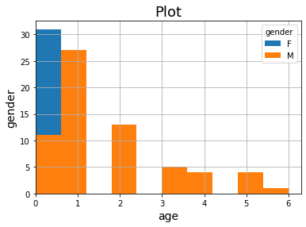

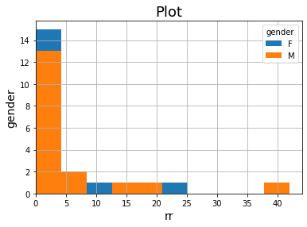

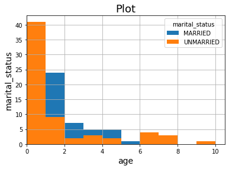

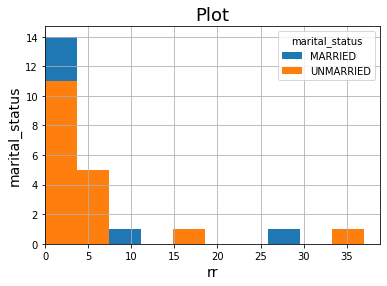

```python
numerical_features_set = ['age','rr']
categorical_features_set = ['gender','marital_status']

for c in categorical_features_set:
    for n in numerical_features_set:
        hist_plot(filter_df[n], filter_df[c], n,c)
```

## Model using sklearn:

### Dummy Variable coding

Remove the response variable from the dataset¶

```python
#X_features = list(filter_df.columns)

X_features = [x for x in filter_df if x not in ['body_weight','body_height',
                                           'creatinine','state_at_the_time_of_arrival',
                                           'total_amount_billed_to_the_patient','concession',
                                          'actual_receivable_amount','total_length_of_stay',
                                          'length_of_stay___icu','length_of_stay__ward',
                                            'total_cost_to_hospital']]
```

```python
X_features
```

```
['age',
 'gender',
 'marital_status',
 'key_complaints__code',
 'hr_pulse',
 'bp__high',
 'bp_low',
 'rr',
 'past_medical_history_code',
 'hb',
 'urea',
 'mode_of_arrival',
 'type_of_admsn',
 'implant_used',
 'cost_of_implant',
 'bmi']
```

```python
categorical_features = ['gender','marital_status','key_complaints__code',
                        'past_medical_history_code','mode_of_arrival','type_of_admsn','implant_used']
```

```python
encoded_X_df = pd.get_dummies(filter_df[X_features], columns = categorical_features, drop_first = True )
```

```python
pd.options.display.max_columns = None
encoded_X_df.info()
```

```
<class 'pandas.core.frame.DataFrame'>
Int64Index: 163 entries, 0 to 162
Data columns (total 25 columns):
age                                       163 non-null float64
hr_pulse                                  163 non-null int64
bp__high                                  163 non-null int64
bp_low                                    163 non-null int64
rr                                        163 non-null int64
hb                                        163 non-null int64
urea                                      163 non-null int64
cost_of_implant                           163 non-null int64
bmi                                       163 non-null float64
gender_M                                  163 non-null uint8
marital_status_UNMARRIED                  163 non-null uint8
key_complaints__code_CAD-DVD              163 non-null uint8
key_complaints__code_CAD-TVD              163 non-null uint8
key_complaints__code_OS-ASD               163 non-null uint8
key_complaints__code_RHD                  163 non-null uint8
key_complaints__code_other- heart         163 non-null uint8
key_complaints__code_other-tertalogy      163 non-null uint8
key_complaints__code_others               163 non-null uint8
past_medical_history_code_diabetes        163 non-null uint8
past_medical_history_code_hypertension    163 non-null uint8
past_medical_history_code_other           163 non-null uint8
mode_of_arrival_TRANSFERRED               163 non-null uint8
mode_of_arrival_WALKED IN                 163 non-null uint8
type_of_admsn_EMERGENCY                   163 non-null uint8
implant_used_Y                            163 non-null uint8
dtypes: float64(2), int64(7), uint8(16)
memory usage: 15.3 KB
```

```python
Y = filter_df.filter(['total_cost_to_hospital'], axis =1)
X = encoded_X_df
Y.info()
```

```
<class 'pandas.core.frame.DataFrame'>
Int64Index: 163 entries, 0 to 162
Data columns (total 1 columns):
total_cost_to_hospital    163 non-null float64
dtypes: float64(1)
memory usage: 2.5 KB
```

### Train and test data split using Python

The train and test split can also be done using the **sklearn module**

```python
from sklearn.model_selection import train_test_split

X_train, X_test, y_train, y_test = train_test_split( X, Y, test_size = 0.3, random_state = 42)
```

## Model Building: Using the **sklearn**

To know about all the methods inside a library use the `dir` command after invoking the library

```python
from sklearn import linear_model
from sklearn.metrics import mean_squared_error, r2_score


#dir(linear_model)
```

```python
# Create linear regression object
ridge_reg_model = linear_model.Ridge(alpha = 0.5) #alpha = 0 is same as simple regression with OLS

# Train the model using the training sets
ridge_reg_model.fit(X_train, y_train)
```

```
Ridge(alpha=0.5, copy_X=True, fit_intercept=True, max_iter=None,
      normalize=False, random_state=None, solver='auto', tol=0.001)
```

Making the model is as simple as calling the `fit` method for `Ridge`. However, since we would like to select the best value of alpha, lets try to do it using the below function.

```python
# Make predictions using the testing set
y_pred = ridge_reg_model.predict(X_train)
```

```python
# The coefficients
print('Coefficients: \n', ridge_reg_model.coef_)
print('Intercept: \n', ridge_reg_model.intercept_)

# The mean squared error
print("Mean squared error: %.2f"
      % mean_squared_error(y_train, y_pred))

# Explained variance score: 1 is perfect prediction
print('Variance score: %.2f' % r2_score(y_train, y_pred))
```

```
Coefficients:
 [[ 2.25248303e+03  8.80058169e+02  4.20155081e+02 -1.30416165e+03
   1.70404750e+03  3.17086582e+02  3.26471159e+02  1.54114159e+00
  -7.74596748e+01  1.60931795e+04  7.28642781e+04  1.29397934e+05
   1.08407954e+05  1.94519608e+04 -6.47066285e+04  3.51853014e+04
   3.88849316e+04 -1.21521337e+04  2.45258104e+04 -2.87679294e+04
  -3.75207123e+04  3.14658040e+04  3.82148625e+04  6.46657323e+04
   1.09438178e+05]]
Intercept:
 [-106175.48194535]
Mean squared error: 8654304253.26
Variance score: 0.56
```

### Random Search with cross validation

To use RandomizedSearchCV, create a parameter grid from where sample will be picked during model building:

```python
alpha = [x for x in np.arange(0.0,5.5,.5)]

# Create the grid
random_grid = {'alpha': alpha}
random_grid
```

```
{'alpha': [0.0, 0.5, 1.0, 1.5, 2.0, 2.5, 3.0, 3.5, 4.0, 4.5, 5.0]}
```

### Model with Grid Search

To report the performance on the selected KPI use `sklearn.metrics.SCORERS.keys()` to get the list of all the metrics and pass the relevant one in `RandomizedSearchCV` or `GridSearchCV`

```python
from sklearn.metrics import SCORERS

SCORERS.keys()
```

```
dict_keys(['explained_variance', 'r2', 'max_error', 'neg_median_absolute_error', 'neg_mean_absolute_error', 'neg_mean_squared_error', 'neg_mean_squared_log_error', 'accuracy', 'roc_auc', 'balanced_accuracy', 'average_precision', 'neg_log_loss', 'brier_score_loss', 'adjusted_rand_score', 'homogeneity…
```

```python
# Use the random grid to search for best hyperparameters
from sklearn.model_selection import GridSearchCV

ridge_reg_model = linear_model.Ridge()

# Random search of parameters, using 3 fold cross validation,
ridge_best_model = GridSearchCV(estimator = ridge_reg_model,
                               param_grid = random_grid, scoring = "r2",
                               cv = 3, verbose=0)
# Fit the random search model
ridge_best_model.fit(X_train, y_train.values.ravel())
```

```
GridSearchCV(cv=3, error_score='raise-deprecating',
             estimator=Ridge(alpha=1.0, copy_X=True, fit_intercept=True,
                             max_iter=None, normalize=False, random_state=None,
                             solver='auto', tol=0.001),
             iid='warn', n_jobs=None,
             param_grid={'alpha': [0.0, 0.5, 1.0, 1.5, 2.0, 2.5, 3.0, 3.5, 4.0,
                                   4.5, 5.0]},
             pre_dispatch='2*n_jobs', refit=True, return_train_score=False,
             scoring='r2', verbose=0)
```

### Report the parameter

The best model has the following parameter selected from the random search grid

```python
ridge_best_model.best_params_
```

```
{'alpha': 1.0}
```

## Model Evaluation

### 1. The prediction on test data.

The prediction can be carried out by **defining functions** as well. Below is one such instance wherein a function is defined and is used for prediction

```python
def get_predictions ( test_actual, model, test_data ):
    df = pd.DataFrame(model.predict(test_data))
    df.columns = ['predicted']
    y_pred_df = pd.concat([test_actual.reset_index(drop=True), df], axis = 1)
    return y_pred_df
```

```python
predict_test_df = pd.DataFrame(get_predictions(y_test.total_cost_to_hospital, ridge_best_model, X_test))
predict_test_df.head()
```

|  | total_cost_to_hospital | predicted |
| --- | --- | --- |
| 0 | 73218.0 | 181899.120495 |
| 1 | 144134.0 | 264746.596520 |
| 2 | 109117.0 | 125295.494626 |
| 3 | 220519.0 | 252008.911393 |
| 4 | 140545.0 | 126609.276605 |

```python
r2_score(predict_test_df.total_cost_to_hospital,predict_test_df.predicted)
mean_squared_error(predict_test_df.total_cost_to_hospital,predict_test_df.predicted)
```

```
0.5681757007558306
```

```
6979439296.831979
```

## Deployment - Save model

Two ways to save the model.

- Using joblib
- Using pickle

```python
from sklearn.externals import joblib
import pickle
```

```python
joblib.dump( ridge_best_model, "ridge_best_model.joblib" )

pickle.dump(ridge_best_model,open("ridge_best_model.pkl",'wb'))
```

```
['ridge_best_model.joblib']
```

## Use model on New Cases

We can load the model object for later use. Assuming that X_test is a new data on which we will want to use the model. We can load the model object in two different ways:

- Using sklearn joblib - This may be useful for some ML algorithms which require a lot of parameters/dataset to be (like K-Nearest Neighbors).
- Using pickle

```python
from sklearn.externals import joblib
import pickle
```

```python
model_joblib = joblib.load( "ridge_best_model.joblib" )
model_pickle = pickle.load(open('ridge_best_model.pkl', 'rb'))
```

Predict on the test set:

```python
model_joblib.predict( X_test )
model_pickle.predict(X_test)
```

```
array([181899.1204952 , 264746.59652022, 125295.49462588, 252008.91139269,
       126609.27660468, 287236.05092449, 121760.92850983, 129858.40941035,
       216233.66409703, 235356.04086705, 307316.87523106, 133649.57167974,
       349006.21531884, 153214.94821853, 319086.16059087, 439060.85784463,
       179563.4841687 , 293135.34988368, 273670.79288087, 155930.21176767,
       271168.87782876, 235772.89945437, 511633.23574066, 236637.03062069,
       170583.12788007, 262022.12422945, 128576.3233739 , 155862.50020625,
       166258.98359231, 339178.0952401 , 126115.67523673, 123143.87003817,
       168580.57727584, 153756.38609904, 338802.4010002 , 171541.85441959,
       206272.59149562, 269792.97689278, 223513.50321958, 293361.94853637,
       268811.4795294 , 241102.33780809, 160460.84863057, 123070.15491174,
        92759.0862434 , 277704.94443381, 195195.10785996, 362204.57029903,
       148905.7248893 ])
```

```
array([181899.1204952 , 264746.59652022, 125295.49462588, 252008.91139269,
       126609.27660468, 287236.05092449, 121760.92850983, 129858.40941035,
       216233.66409703, 235356.04086705, 307316.87523106, 133649.57167974,
       349006.21531884, 153214.94821853, 319086.16059087, 439060.85784463,
       179563.4841687 , 293135.34988368, 273670.79288087, 155930.21176767,
       271168.87782876, 235772.89945437, 511633.23574066, 236637.03062069,
       170583.12788007, 262022.12422945, 128576.3233739 , 155862.50020625,
       166258.98359231, 339178.0952401 , 126115.67523673, 123143.87003817,
       168580.57727584, 153756.38609904, 338802.4010002 , 171541.85441959,
       206272.59149562, 269792.97689278, 223513.50321958, 293361.94853637,
       268811.4795294 , 241102.33780809, 160460.84863057, 123070.15491174,
        92759.0862434 , 277704.94443381, 195195.10785996, 362204.57029903,
       148905.7248893 ])
```

Model performance on the test set

```python
model_joblib.score(X_test,y_test)
model_pickle.score(X_test, y_test)
```

```
0.5681757007558306
```

```
0.5681757007558306
```